# Final Project: [Diabetes Prediction Data Set](https://www.kaggle.com/datasets/marshalpatel3558/diabetes-prediction-dataset)

M. Ashura Langford

Student ID: 004001453

```python
import pandas as pd
import plotly.express as px
import numpy as np
import matplotlib.pyplot as plt
import seaborn as sns
import matplotlib.patches as mpatches


df = pd.read_csv('diabetes_dataset.csv')
data= df.copy()
```

## Data Cleaning and Understanding

```python
data.head()
data.info()
data.describe()
```

```
<class 'pandas.core.frame.DataFrame'>
RangeIndex: 10000 entries, 0 to 9999
Data columns (total 21 columns):
 #   Column                         Non-Null Count  Dtype
---  ------                         --------------  -----
 0   Unnamed: 0                     10000 non-null  int64
 1   Age                            10000 non-null  int64
 2   Sex                            10000 non-null  object
 3   Ethnicity                      10000 non-null  object
 4   BMI                            10000 non-null  float64
 5   Waist_Circumference            10000 non-null  float64
 6   Fasting_Blood_Glucose          10000 non-null  float64
 7   HbA1c                          10000 non-null  float64
 8   Blood_Pressure_Systolic        10000 non-null  int64
 9   Blood_Pressure_Diastolic       10000 non-null  int64
 10  Cholesterol_Total              10000 non-null  float64
 11  Cholesterol_HDL                10000 non-null  float64
 12  Cholesterol_LDL                10000 non-null  float64
 13  GGT                            10000 non-null  float64
 14  Serum_Urate                    10000 non-null  float64
 15  Physical_Activity_Level        10000 non-null  object
 16  Dietary_Intake_Calories        10000 non-null  int64
 17  Alcohol_Consumption            6680 non-null   object
 18  Smoking_Status                 10000 non-null  object
 19  Family_History_of_Diabetes     10000 non-null  int64
 20  Previous_Gestational_Diabetes  10000 non-null  int64
dtypes: float64(9), int64(7), object(5)
memory usage: 1.6+ MB
```

|  | Unnamed: 0 | Age | BMI | Waist_Circumference | Fasting_Blood_Glucose | HbA1c | Blood_Pressure_Systolic | Blood_Pressure_Diastolic | Cholesterol_Total | Cholesterol_HDL | Cholesterol_LDL | GGT | Serum_Urate | Dietary_Intake_Calories | Family_History_of_Diabetes | Previous_Gestational_Diabetes |
| --- | --- | --- | --- | --- | --- | --- | --- | --- | --- | --- | --- | --- | --- | --- | --- | --- |
| count | 10000.00000 | 10000.000000 | 10000.000000 | 10000.00000 | 10000.000000 | 10000.000000 | 10000.000000 | 10000.000000 | 10000.000000 | 10000.000000 | 10000.00000 | 10000.00000 | 10000.000000 | 10000.000000 | 10000.000000 | 10000.000000 |
| mean | 4999.50000 | 44.620400 | 29.418150 | 94.79707 | 134.776210 | 9.507510 | 134.163700 | 89.558700 | 225.165540 | 55.019340 | 134.35377 | 55.16822 | 5.503430 | 2742.481900 | 0.507000 | 0.516500 |
| std | 2886.89568 | 14.343489 | 6.170866 | 14.38329 | 37.633544 | 3.176421 | 26.110317 | 17.237792 | 42.963744 | 14.537371 | 37.50238 | 25.88180 | 1.455091 | 716.643803 | 0.499976 | 0.499753 |
| min | 0.00000 | 20.000000 | 18.500000 | 70.00000 | 70.000000 | 4.000000 | 90.000000 | 60.000000 | 150.000000 | 30.000000 | 70.00000 | 10.00000 | 3.000000 | 1500.000000 | 0.000000 | 0.000000 |
| 25% | 2499.75000 | 32.000000 | 24.100000 | 82.20000 | 102.175000 | 6.800000 | 112.000000 | 75.000000 | 187.875000 | 42.300000 | 101.67500 | 32.60000 | 4.200000 | 2129.000000 | 0.000000 | 0.000000 |
| 50% | 4999.50000 | 45.000000 | 29.500000 | 94.90000 | 134.500000 | 9.500000 | 134.000000 | 89.000000 | 225.500000 | 55.200000 | 134.40000 | 55.45000 | 5.500000 | 2727.000000 | 1.000000 | 1.000000 |
| 75% | 7499.25000 | 57.000000 | 34.700000 | 107.00000 | 167.800000 | 12.300000 | 157.000000 | 105.000000 | 262.400000 | 67.900000 | 166.40000 | 77.50000 | 6.800000 | 3368.000000 | 1.000000 | 1.000000 |
| max | 9999.00000 | 69.000000 | 40.000000 | 120.00000 | 200.000000 | 15.000000 | 179.000000 | 119.000000 | 300.000000 | 80.000000 | 200.00000 | 100.00000 | 8.000000 | 3999.000000 | 1.000000 | 1.000000 |

```python
print(data.isnull().sum())
print(f'Duplicated:',data.duplicated().sum())
```

```
Unnamed: 0                          0
Age                                 0
Sex                                 0
Ethnicity                           0
BMI                                 0
Waist_Circumference                 0
Fasting_Blood_Glucose               0
HbA1c                               0
Blood_Pressure_Systolic             0
Blood_Pressure_Diastolic            0
Cholesterol_Total                   0
Cholesterol_HDL                     0
Cholesterol_LDL                     0
GGT                                 0
Serum_Urate                         0
Physical_Activity_Level             0
Dietary_Intake_Calories             0
Alcohol_Consumption              3320
Smoking_Status                      0
Family_History_of_Diabetes          0
Previous_Gestational_Diabetes       0
dtype: int64
Duplicated: 0
```

**Explanation:** I decided to drop the unknown column as it provided no relevance in the data analysis. There were no duplicated values, but there is a high number of missing values(3,320) in the Alcohol Consumption column. Due to this high number of missing values, I will do data imputation.

```python
data = data.drop('Unnamed: 0', axis=1)
alcohol_mode = data['Alcohol_Consumption'].mode()[0]
data['Alcohol_Consumption'].fillna(alcohol_mode, inplace=True)
```

**Explanation:** Due to the high number of missing values, dropping the Alcohol Consumption Cateogory would lead to a substantial loss of information. This could potentially produce selection bias. The cateogorical nature of this column led me to do a mode imputation to fill in those missing values. The mode was moderate,so by imputing the mode I can preserve the sample size and maintaint the overall distribution of data.

```python
black_alcohol_consumers = data[(data['Ethnicity'] == 'Black') & (data['Alcohol_Consumption'] != 'None')]

print(f"Number of Black Alcohol Consumers: {len(black_alcohol_consumers)}")
black_alcohol_consumers.head()
```

```
Number of Black Alcohol Consumers: 2539
```

|  | Age | Sex | Ethnicity | BMI | Waist_Circumference | Fasting_Blood_Glucose | HbA1c | Blood_Pressure_Systolic | Blood_Pressure_Diastolic | Cholesterol_Total | Cholesterol_HDL | Cholesterol_LDL | GGT | Serum_Urate | Physical_Activity_Level | Dietary_Intake_Calories | Alcohol_Consumption | Smoking_Status | Family_History_of_Diabetes | Previous_Gestational_Diabetes |
| --- | --- | --- | --- | --- | --- | --- | --- | --- | --- | --- | --- | --- | --- | --- | --- | --- | --- | --- | --- | --- |
| 2 | 34 | Female | Black | 25.0 | 113.8 | 142.0 | 14.5 | 179 | 104 | 261.0 | 32.1 | 164.1 | 56.2 | 6.9 | Low | 1684 | Heavy | Former | 1 | 0 |
| 6 | 58 | Male | Black | 33.2 | 100.0 | 97.7 | 13.3 | 131 | 80 | 199.8 | 77.9 | 73.4 | 52.1 | 4.7 | High | 3107 | Moderate | Never | 0 | 0 |
| 10 | 30 | Male | Black | 21.9 | 86.5 | 124.8 | 6.0 | 104 | 111 | 295.4 | 53.7 | 182.3 | 88.8 | 3.8 | Low | 2836 | Heavy | Current | 1 | 0 |
| 13 | 59 | Male | Black | 38.7 | 119.0 | 167.5 | 10.2 | 152 | 87 | 225.4 | 54.0 | 179.6 | 91.7 | 5.7 | Low | 1529 | Moderate | Never | 0 | 0 |
| 17 | 21 | Female | Black | 27.3 | 117.3 | 131.7 | 13.3 | 107 | 105 | 211.5 | 64.0 | 154.9 | 60.8 | 3.4 | Moderate | 1897 | Heavy | Former | 1 | 1 |

**Explanation:** To look at specific groups of people, I can filter the data to show me people who are a part of a particular group. In this example, I filtered to look at black participants who reported consuming moderate to heavy amounts of alcohol. This allows me to see if there is a relationship between alcohol consumption and ethnicity, while also looking at other sections of data like BMI.

```python
bmi_bins=[0,18.5,25.0,30.0, float('inf')]#based on standard health ranges
bmi_labels= ['Underweight','Normal Weight', 'Overweight', 'Obese']
data['BMI_Category'] = pd.cut(
    data['BMI'],
    bins=bmi_bins,
    labels=bmi_labels,
    right=False
)
print("BMI Category Counts:")
print(data['BMI_Category'].value_counts())

glucose_bins= [0, 5.7, 6.5, float('inf')]
glucose_labels=['Normal', 'Pre-diabetes', 'Diabetes']
data['Glucose_Control_Status'] = pd.cut(
    data['HbA1c'],
    bins= glucose_bins,
    labels= glucose_labels,
    right= False
)
print("\n GLucose Control Status")
print(data["Glucose_Control_Status"].value_counts())

age_bins = [0, 30, 50, 65, float('inf')]
age_labels = ['Young Adult', 'Middle-Aged', 'Senior', 'Elderly']
data['Age_Group'] = pd.cut(
    data['Age'],
    bins=age_bins,
    labels=age_labels,
    right=False
)
print("\n Age Category")
print(data['Age_Group'].value_counts())
```

```
BMI Category Counts:
BMI_Category
Obese            4785
Normal Weight    2856
Overweight       2359
Underweight         0
Name: count, dtype: int64

 GLucose Control Status
Glucose_Control_Status
Diabetes        7784
Normal          1471
Pre-diabetes     745
Name: count, dtype: int64

 Age Category
Age_Group
Middle-Aged    4094
Senior         2985
Young Adult    1922
Elderly         999
Name: count, dtype: int64
```

**Explanation:** I createed a new categorical column for BMI, Age, and glucose to assist in future data visualization, and to also see the difference in populations. I was able to find sources that provided the parameters for each category([NHF Inform:BMI](https://www.nhsinform.scot/healthy-living/weight-loss/understanding-healthy-weight/how-do-i-measure-my-body-mass-index-bmi))([CDC: glucose](https://www.cdc.gov/diabetes/diabetes-testing/prediabetes-a1c-test.html#:~:text=A1C%20results,Diabetes%3A%206.5%25%20or%20above)).

```python
categorical_cols1 = ['Sex', 'Ethnicity', 'Physical_Activity_Level', 'Smoking_Status', 'Alcohol_Consumption', 'Family_History_of_Diabetes', 'Previous_Gestational_Diabetes']

for col in categorical_cols1:
        data[col] = data[col].astype('category')

numeric_cols = [
    'Age', 'BMI', 'Waist_Circumference', 'Fasting_Blood_Glucose', 'HbA1c',
    'Blood_Pressure_Systolic', 'Blood_Pressure_Diastolic',
    'Cholesterol_Total', 'Cholesterol_HDL', 'Cholesterol_LDL',
    'GGT', 'Serum_Urate'
]
for col in numeric_cols:
    data[col] = pd.to_numeric(data[col], errors='coerce')

for col in numeric_cols:
    if data[col].isnull().any():
        data[col].fillna(data[col].mean(), inplace=True)
```

```python
print("Summary Statistics of Continuous Variables")
print(data.describe().T)
print("\n Unique Values for Categorical Variables")
categorical_cols2 = ['Sex', 'Ethnicity', 'Physical_Activity_Level',
                    'Alcohol_Consumption', 'Smoking_Status',
                    'Family_History_of_Diabetes', 'Previous_Gestational_Diabetes',
                    'BMI_Category', 'Glucose_Control_Status', 'Age_Group']

for col in categorical_cols2:
    print(f"\n{col}:")
    print(data[col].value_counts())
```

```
Summary Statistics of Continuous Variables
                            count        mean         std     min       25%  \
Age                       10000.0    44.62040   14.343489    20.0    32.000
BMI                       10000.0    29.41815    6.170866    18.5    24.100
Waist_Circumference       10000.0    94.79707   14.383290    70.0    82.200
Fasting_Blood_Glucose     10000.0   134.77621   37.633544    70.0   102.175
HbA1c                     10000.0     9.50751    3.176421     4.0     6.800
Blood_Pressure_Systolic   10000.0   134.16370   26.110317    90.0   112.000
Blood_Pressure_Diastolic  10000.0    89.55870   17.237792    60.0    75.000
Cholesterol_Total         10000.0   225.16554   42.963744   150.0   187.875
Cholesterol_HDL           10000.0    55.01934   14.537371    30.0    42.300
Cholesterol_LDL           10000.0   134.35377   37.502380    70.0   101.675
GGT                       10000.0    55.16822   25.881800    10.0    32.600
Serum_Urate               10000.0     5.50343    1.455091     3.0     4.200
Dietary_Intake_Calories   10000.0  2742.48190  716.643803  1500.0  2129.000

                              50%     75%     max
Age                         45.00    57.0    69.0
BMI                         29.50    34.7    40.0
Waist_Circumference         94.90   107.0   120.0
Fasting_Blood_Glucose      134.50   167.8   200.0
HbA1c                        9.50    12.3    15.0
Blood_Pressure_Systolic    134.00   157.0   179.0
Blood_Pressure_Diastolic    89.00   105.0   119.0
Cholesterol_Total          225.50   262.4   300.0
Cholesterol_HDL             55.20    67.9    80.0
Cholesterol_LDL            134.40   166.4   200.0
GGT                         55.45    77.5   100.0
Serum_Urate                  5.50     6.8     8.0
Dietary_Intake_Calories   2727.00  3368.0  3999.0

 Unique Values for Categorical Variables

Sex:
Sex
Female    5005
Male      4995
Name: count, dtype: int64

Ethnicity:
```

[output cut: 46 more lines]

```

Glucose_Control_Status:
Glucose_Control_Status
Diabetes        7784
Normal          1471
Pre-diabetes     745
Name: count, dtype: int64

Age_Group:
Age_Group
Middle-Aged    4094
Senior         2985
Young Adult    1922
Elderly         999
Name: count, dtype: int64
```

## Data Visualization

### Heatmap

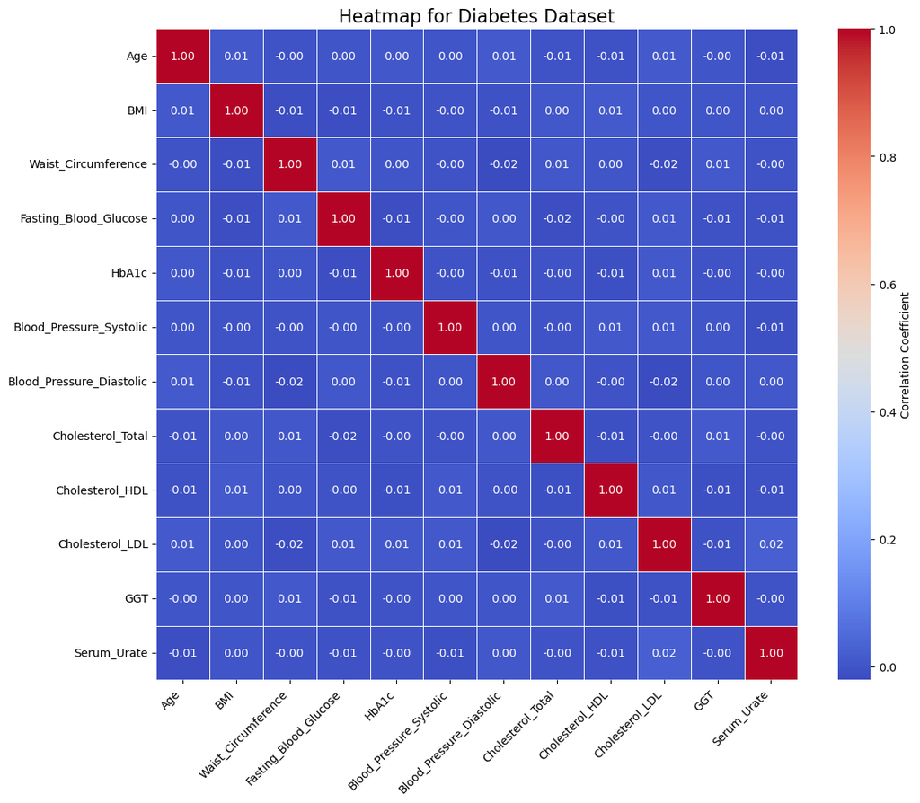

```python
numeric_cols = [
    'Age', 'BMI', 'Waist_Circumference', 'Fasting_Blood_Glucose', 'HbA1c',
    'Blood_Pressure_Systolic', 'Blood_Pressure_Diastolic',
    'Cholesterol_Total', 'Cholesterol_HDL', 'Cholesterol_LDL',
    'GGT', 'Serum_Urate'
]
correlation_matrix = data[numeric_cols].corr()

plt.figure(figsize = (12, 10))
sns.heatmap(
    correlation_matrix,
    annot = True,
    fmt = ".2f",
    cmap = 'coolwarm',
    linewidths = .5,
    cbar_kws = {'label': 'Correlation Coefficient'}
)
plt.title('Heatmap for Diabetes Dataset', fontsize = 16)
plt.xticks(rotation = 45, ha = 'right')
plt.yticks(rotation = 0)
plt.tight_layout()
plt.savefig('heatmap_correlation_matrix.png')
plt.show()
```

### Family History v. Gender: Countplot

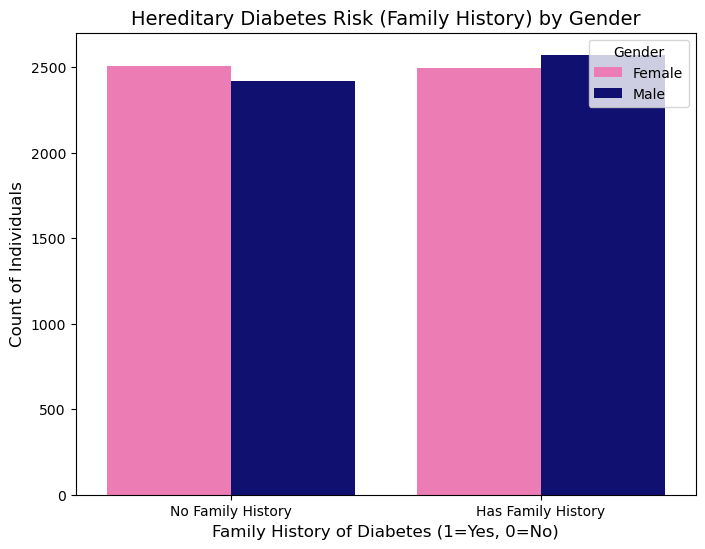

```python
plt.figure(figsize=(8, 6))
sns.countplot(
    data=data,
    x='Family_History_of_Diabetes',
    hue='Sex',
    palette=['hotpink', 'navy']
)
plt.title('Hereditary Diabetes Risk (Family History) by Gender', fontsize=14)
plt.xlabel('Family History of Diabetes (1=Yes, 0=No)', fontsize=12)
plt.ylabel('Count of Individuals', fontsize=12)

plt.xticks(ticks=[0, 1], labels=['No Family History', 'Has Family History'])

plt.legend(title='Gender')
plt.savefig('family_gender_countplot.png')
plt.show()
```

**Interpretation:** This visualization shows a highly balanced distribution of possible hereditary risk across the entire population sample. I say this because the number of individuals with a family history(5070) is almost equal to those without(4930). When separated by gender, the plot reveals that among those who don't have a family history, females slightly outnumber males, but it is the opposite for those who do have a family history. This suggests that while hereditary risks are prevalent, the male subgroup in this data shows a slightly greater predisposition based on family history.

### BMI by Ethnicity: Box plot

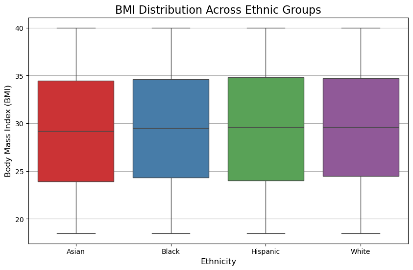

```python
plt.figure(figsize=(10, 6))
sns.boxplot(
    data=data,
    x='Ethnicity',
    y='BMI',
    palette='Set1'
)

plt.title('BMI Distribution Across Ethnic Groups', fontsize=16)
plt.xlabel('Ethnicity', fontsize=12)
plt.ylabel('Body Mass Index (BMI)', fontsize=12)
plt.grid(axis='y')
plt.savefig('BMI_Ethnic_Boxplot.png')
plt.show()
```

### Fasting Blood Glucose: Histogram

```python
conditions = [
    (data['Fasting_Blood_Glucose'] < 100),
    (data['Fasting_Blood_Glucose'] >= 100) & (data['Fasting_Blood_Glucose'] < 126),
    (data['Fasting_Blood_Glucose'] >= 126)
]

choices = [
    'Normal Range (< 100)',
    'Pre-Diabetes Risk (100-125)',
    'Diabetes (>= 126)'
]

data['FBG_3_Risk_Level'] = np.select(conditions, choices, default='Error')

data['FBG_3_Risk_Level'] = data['FBG_3_Risk_Level'].astype('category')

print("3-Level FBG Risk Distribution:")
print(data['FBG_3_Risk_Level'].value_counts())
```

```
3-Level FBG Risk Distribution:
FBG_3_Risk_Level
Diabetes (>= 126)              5671
Normal Range (< 100)           2322
Pre-Diabetes Risk (100-125)    2007
Name: count, dtype: int64
```

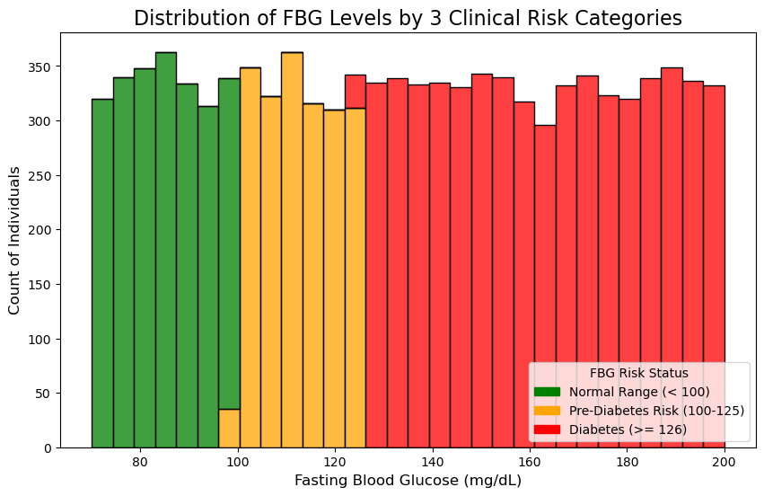

```python
import matplotlib.patches as mpatches

plt.figure(figsize=(10, 6))

custom_palette = {
    'Normal Range (< 100)': 'green',
    'Pre-Diabetes Risk (100-125)': 'orange',
    'Diabetes (>= 126)': 'red'
}

sns.histplot(
    data=data,
    x='Fasting_Blood_Glucose',
    bins=30,
    hue='FBG_3_Risk_Level',
    multiple='stack',
    palette=custom_palette,
    kde=False
)


import matplotlib.patches as mpatches

handles = [mpatches.Patch(color=custom_palette[label], label=label) for label in custom_palette]

plt.legend(
    handles=handles,
    title='FBG Risk Status',
    loc='lower right'
)

plt.title('Distribution of FBG Levels by 3 Clinical Risk Categories', fontsize=16)
plt.xlabel('Fasting Blood Glucose (mg/dL)', fontsize=12)
plt.ylabel('Count of Individuals', fontsize=12)
plt.savefig('FBG_dis_histogram.png')
plt.show()
```

### HbA1C by Activity Level: Violin Plot

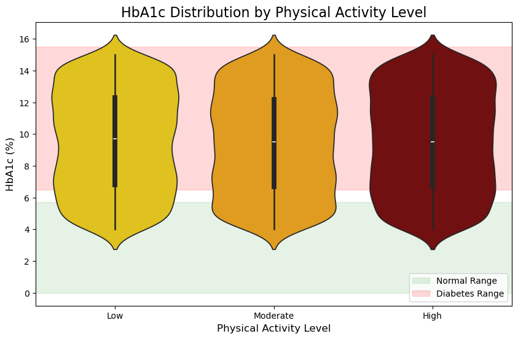

```python
NORMAL_MAX = 5.7
DIABETES_MIN = 6.5
DATA_MAX = data['HbA1c'].max()
plt.figure(figsize=(10, 6))
plt.axhspan(0, NORMAL_MAX, color='green', alpha=0.1, label='Normal Range')
plt.axhspan(DIABETES_MIN, DATA_MAX + 0.5, color='red', alpha=0.15, label='Diabetes Range')

sns.violinplot(
    data=data,
    x='Physical_Activity_Level',
    y='HbA1c',
    order=['Low', 'Moderate', 'High'],
    palette=['gold','orange','maroon']
)


plt.title('HbA1c Distribution by Physical Activity Level', fontsize=16)
plt.xlabel('Physical Activity Level', fontsize=12)
plt.ylabel('HbA1c (%)', fontsize=12)
plt.legend(loc='lower right')
plt.savefig('hbA1c_activity_violinplot.png')
plt.show()
```

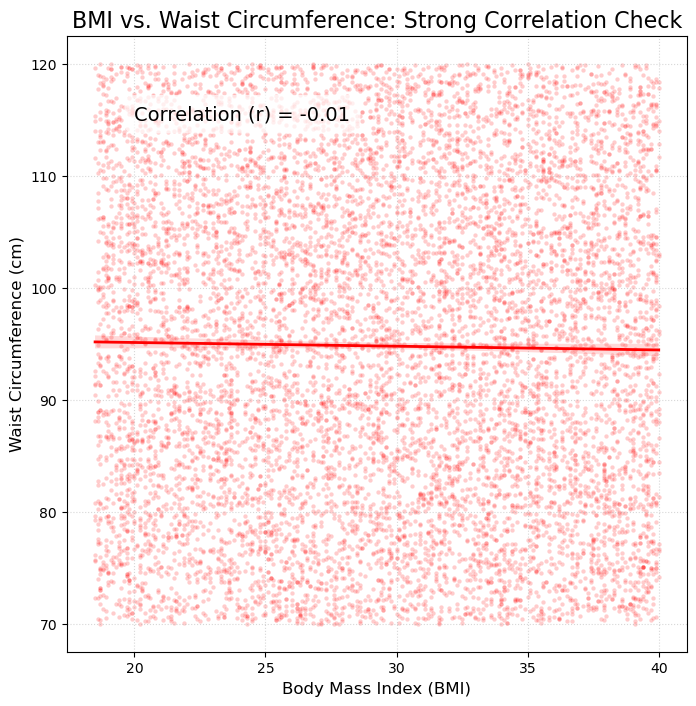

```python
r_value = data['BMI'].corr(data['Waist_Circumference'])

plt.figure(figsize=(8, 8))

sns.scatterplot(
    data=data,
    x='BMI',
    y='Waist_Circumference',
    alpha=0.2,
    s=10,
    color='red'
)

sns.regplot(
    data=data,
    x='BMI',
    y='Waist_Circumference',
    scatter=False,
    color='red',
    line_kws={'linestyle': '-', 'linewidth': 2}
)

annotation_text = f"Correlation (r) = {r_value:.2f}"

plt.text(
    x=20,
    y=115,
    s=annotation_text,
    fontsize=14,
    color='black',
    bbox=dict(facecolor='white', alpha=0.7, edgecolor='none', boxstyle='round,pad=0.5')
)

plt.title('BMI vs. Waist Circumference: Strong Correlation Check', fontsize=16)
plt.xlabel('Body Mass Index (BMI)', fontsize=12)
plt.ylabel('Waist Circumference (cm)', fontsize=12)
plt.grid(True, linestyle=':', alpha=0.5)
plt.savefig('BMI_Waist_scatterplot.png')
plt.show()
```

**Interpretation:** This scatter plot visualizes a relatively weak negative correlation between waist circumference, which suggests that waist circumference is not a good predictor for BMI.

## Animated Visualizations

### How does the distribution of high-risk glucose categories (Pre-diabetes and Diabetes) evolve across BMI Categories as the population ages? *Using an Animated Stacked Bar Plot*

```python
risk_progression = data.groupby(['Age_Group', 'BMI_Category', 'Glucose_Control_Status']).size().reset_index(name='Count')

age_order = ['Young Adult', 'Middle-Aged', 'Senior', 'Elderly']
bmi_order = ['Underweight', 'Normal Weight', 'Overweight', 'Obese']
glucose_order = ['Normal', 'Pre-diabetes', 'Diabetes'] # Stack order

fig = px.bar(
    risk_progression,
    x="BMI_Category",
    y="Count",
    color="Glucose_Control_Status",
    animation_frame="Age_Group",
    category_orders={
        "Age_Group": age_order,
        "BMI_Category": bmi_order,
        "Glucose_Control_Status": glucose_order
    },
    title="Evolution of Glucose Risk Across BMI Categories by Age"
)

fig.update_layout(
    xaxis_title="BMI Category",
    yaxis_title="Count of Individuals",
    legend_title="Glucose Status"
)

fig.show()
fig.write_html("BMI_Age_status.html")
```

[interactive chart not shown]

**Interpretation:** This animated visual shows the progression of BMI and glucose categories across age groups. This provided an insightful view into the intersection of obesity and aging as possible driving factors of diabetes risk. This population mostly consists of middle-aged individuals, and when looking at that age group, the obese group is made up mostly of those with diabetes. Based on this visual, it can be said that middle age and higher BMI could put individuals at a higher risk of diabetes. Overall, the obese group had a higher count of individuals with diabetes across all groups.

### How does the proportion of individuals in different BMI categories look across categories like sex, age, and ethnicity? *Using a sunburst plot*

```python
path = ['Ethnicity', 'Age_Group', 'BMI_Category', 'Sex']

fig = px.sunburst(
    data,
    path=path,
    color='Ethnicity',
    title="Hierarchical Breakdown of Population by BMI Category and Demographics (Interactive)"
)

fig.update_traces(hovertemplate='<b>%{label}</b><br>Count: %{value}<extra></extra>')
fig.show()
fig.write_html("sunburst.html")
```

[interactive chart not shown]

**Interpreation:** This interactive plot provides a ranked analysis of the population in their respective BMI categories. There aren't any drastic differences across BMI categories when looking at different ethnic groups and sex, however similar to what was previously seen there is a drastci difference among age groups.

### How does the trade-off between the two primary cardiovascular risk factors(Blood Pressure and Cholesterol) differ between individuals with a normal glucose status versus those with diabetes? *Using box plots*

```python
risk_order = ['Normal', 'Pre-diabetes', 'Diabetes']
age_order = ['Young Adult', 'Middle-Aged', 'Senior', 'Elderly']
custom_palette = {
    'Normal': 'green',
    'Pre-diabetes': 'orange',
    'Diabetes': 'red'
}


metrics_to_melt = ['Cholesterol_Total', 'Blood_Pressure_Systolic']
data_long = pd.melt(
    data,
    id_vars=['Age_Group', 'Glucose_Control_Status'],
    value_vars=metrics_to_melt,
    var_name='Metric',
    value_name='Value'
)

fig_combined = px.box(
    data_long,
    x='Age_Group',
    y='Value',
    color='Glucose_Control_Status',
    facet_row='Metric',

    category_orders={
        'Age_Group': age_order,
        'Glucose_Control_Status': risk_order,
        'Metric': metrics_to_melt
    },
    color_discrete_map=custom_palette,
    points='all',
    title='Distribution of Cardiovascular Risk Metrics by Age and Glucose Status(Interactive)'
)

fig_combined.update_layout(height=800, showlegend=True)
fig_combined.for_each_annotation(lambda a: a.update(text=a.text.replace('Metric=', '')))

fig_combined.show()
fig.write_html("Glucose_cholestorolBP_boxplot.html")
```

[interactive chart not shown]